# Country Report Switzerland

Valentin

18/01/2020

# Switzerland main economic indicators

## Analysis of the GDP

|  | iso2c | country | NY.GDP.MKTP.KD.ZG | year |
| --- | --- | --- | --- | --- |
| 1 | CH | Switzerland | 2.75051698 | 2018 |
| 2 | CH | Switzerland | 1.79947669 | 2017 |
| 3 | CH | Switzerland | 1.72264911 | 2016 |
| 4 | CH | Switzerland | 1.33338850 | 2015 |
| 5 | CH | Switzerland | 2.44917953 | 2014 |
| 6 | CH | Switzerland | 1.85203545 | 2013 |
| 7 | CH | Switzerland | 1.00607781 | 2012 |
| 8 | CH | Switzerland | 1.69275218 | 2011 |
| 9 | CH | Switzerland | 3.00279825 | 2010 |
| 10 | CH | Switzerland | -2.22211194 | 2009 |

[output cut: 38 more lines]

|  | country | NY.GDP.MKTP.KD.ZG | year |
| --- | --- | --- | --- |
| 1 | Switzerland | 2.75051698 | 2018 |
| 2 | Switzerland | 1.79947669 | 2017 |
| 3 | Switzerland | 1.72264911 | 2016 |
| 4 | Switzerland | 1.33338850 | 2015 |
| 5 | Switzerland | 2.44917953 | 2014 |
| 6 | Switzerland | 1.85203545 | 2013 |
| 7 | Switzerland | 1.00607781 | 2012 |
| 8 | Switzerland | 1.69275218 | 2011 |
| 9 | Switzerland | 3.00279825 | 2010 |
| 10 | Switzerland | -2.22211194 | 2009 |

[output cut: 38 more lines]

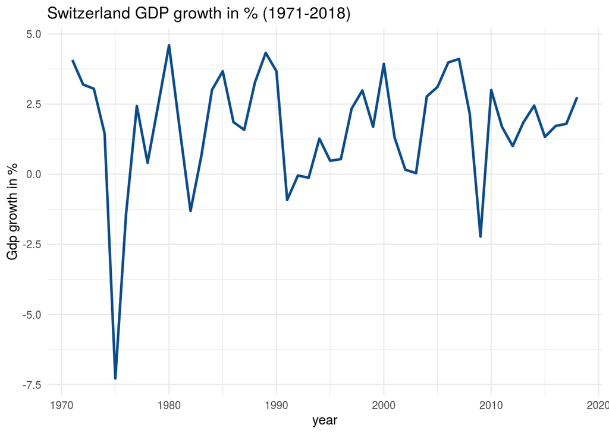

```
##    Min. 1st Qu.  Median    Mean 3rd Qu.    Max.
## -7.2832  0.6143  1.8258  1.6789  3.0188  4.6020
```

### Conclusion about the GDP growth in %

As we can see on the graph, the Switzerland GDP growth is sometimes under 0, but the most of the time, it’s higher than 0. To better understand these data, i have choosen to compute the mean (1,68) and the median (1,82) of the GDP growth on the period 1971 - 2018. As we can see on the graphic, there is an important decrease in 1975 due to the first oil crisis.

## Comparison with three european countries (France, Italy, Germany)

|  | iso2c | country | NY.GDP.MKTP.KD.ZG | year |
| --- | --- | --- | --- | --- |
| 1 | CH | Switzerland | 2.750516981 | 2018 |
| 2 | CH | Switzerland | 1.799476694 | 2017 |
| 3 | CH | Switzerland | 1.722649108 | 2016 |
| 4 | CH | Switzerland | 1.333388501 | 2015 |
| 5 | CH | Switzerland | 2.449179525 | 2014 |
| 6 | CH | Switzerland | 1.852035453 | 2013 |
| 7 | CH | Switzerland | 1.006077812 | 2012 |
| 8 | CH | Switzerland | 1.692752180 | 2011 |
| 9 | CH | Switzerland | 3.002798245 | 2010 |
| 10 | CH | Switzerland | -2.222111937 | 2009 |

[output cut: 182 more lines]

### Comparison of the data between the 4 countries

| country | mean_gdp | max_gdp | min_gdp | median_gdp |
| --- | --- | --- | --- | --- |
| France | 2.194649 | 6.344581 | -2.873314 | 2.149698 |
| Germany | 1.995932 | 5.255006 | -5.697152 | 1.973560 |
| Italy | 1.730664 | 7.125862 | -5.280937 | 1.714732 |
| Switzerland | 1.678856 | 4.601977 | -7.283175 | 1.825756 |

### Conclusion about the comparison

As we can see, Switzerland doesn’t have the best results in terms of the variation of his GDP. In fact, Switzerland has the worst results compared to this others countries. It’ll be interesting to understand why Switzerland has a better economy than these 3 countries even if the results about the variation of his gdp are less good than his neighbours.

## Analysis of the GDP per capita of Switzerland

|  | iso2c | country | NY.GDP.PCAP.PP.CD | year |
| --- | --- | --- | --- | --- |
| 1 | CH | Switzerland | 68060.94 | 2018 |
| 2 | CH | Switzerland | 66395.86 | 2017 |
| 3 | CH | Switzerland | 64323.93 | 2016 |
| 4 | CH | Switzerland | 63938.99 | 2015 |
| 5 | CH | Switzerland | 61902.13 | 2014 |
| 6 | CH | Switzerland | 60108.52 | 2013 |
| 7 | CH | Switzerland | 57849.57 | 2012 |
| 8 | CH | Switzerland | 56183.82 | 2011 |
| 9 | CH | Switzerland | 53067.72 | 2010 |
| 10 | CH | Switzerland | 51769.03 | 2009 |

[output cut: 19 more lines]

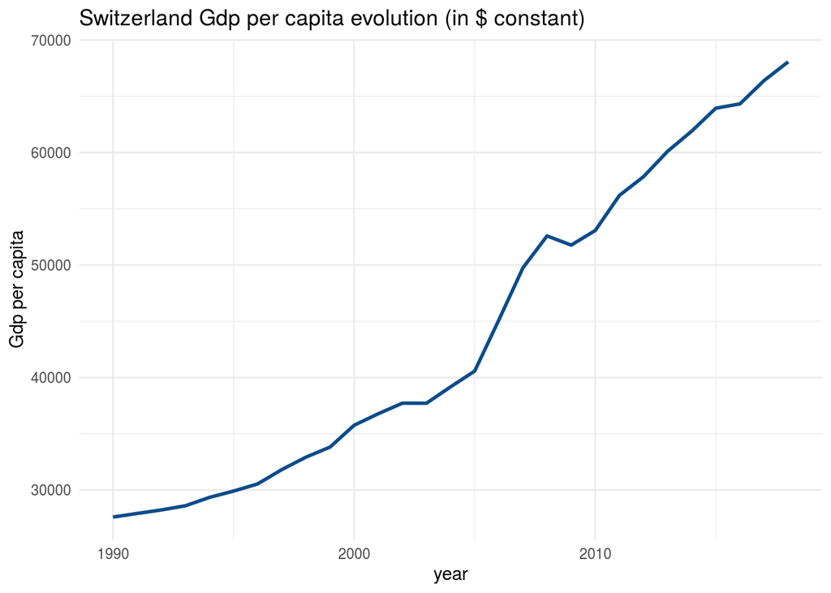

### Conclusion about the evolution of the GDP per capita of Switzerland

We can see that the GDP per capita increase during this period, he was at 27594.63 in 1990 and at 68060.94 in 2018 (146,6% increase). It’ll be now interesting to compare with the three others countries to see if Switzerland is better in this category.

## Comparison with three european countries (France, Italy, Germany)

|  | iso2c | country | NY.GDP.PCAP.PP.CD | year |
| --- | --- | --- | --- | --- |
| 1 | CH | Switzerland | 68060.94 | 2018 |
| 2 | CH | Switzerland | 66395.86 | 2017 |
| 3 | CH | Switzerland | 64323.93 | 2016 |
| 4 | CH | Switzerland | 63938.99 | 2015 |
| 5 | CH | Switzerland | 61902.13 | 2014 |
| 6 | CH | Switzerland | 60108.52 | 2013 |
| 7 | CH | Switzerland | 57849.57 | 2012 |
| 8 | CH | Switzerland | 56183.82 | 2011 |
| 9 | CH | Switzerland | 53067.72 | 2010 |
| 10 | CH | Switzerland | 51769.03 | 2009 |

[output cut: 106 more lines]

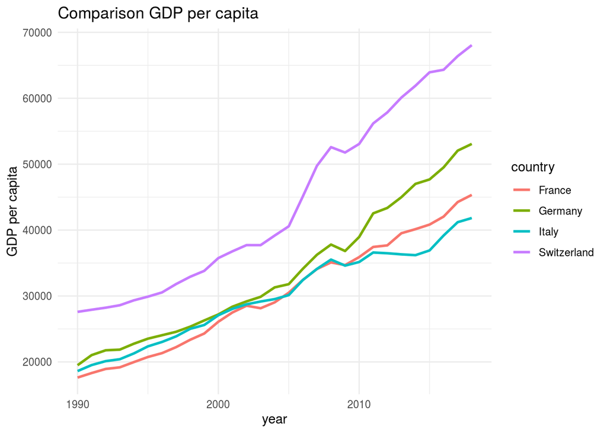

## How Switzerland deals with unemployment?

|  | iso2c | country | SL.UEM.ADVN.ZS | year |
| --- | --- | --- | --- | --- |
| 1 | CH | Switzerland | 3.4768 | 2018 |
| 2 | CH | Switzerland | 3.7398 | 2017 |
| 3 | CH | Switzerland | 3.3240 | 2016 |
| 4 | CH | Switzerland | 3.5191 | 2015 |
| 5 | CH | Switzerland | 3.4334 | 2014 |
| 6 | CH | Switzerland | 3.3651 | 2013 |
| 7 | CH | Switzerland | 3.0304 | 2012 |
| 8 | CH | Switzerland | 2.9646 | 2011 |
| 9 | CH | Switzerland | 3.0952 | 2010 |
| 10 | CH | Switzerland | 2.7361 | 2009 |

[output cut: 11 more lines]

|  | iso2c | country | Advanced_Education | year |
| --- | --- | --- | --- | --- |
| 1 | CH | Switzerland | 3.4768 | 2018 |
| 2 | CH | Switzerland | 3.7398 | 2017 |
| 3 | CH | Switzerland | 3.3240 | 2016 |
| 4 | CH | Switzerland | 3.5191 | 2015 |
| 5 | CH | Switzerland | 3.4334 | 2014 |
| 6 | CH | Switzerland | 3.3651 | 2013 |
| 7 | CH | Switzerland | 3.0304 | 2012 |
| 8 | CH | Switzerland | 2.9646 | 2011 |
| 9 | CH | Switzerland | 3.0952 | 2010 |
| 10 | CH | Switzerland | 2.7361 | 2009 |

[output cut: 11 more lines]

|  | iso2c | country | SL.UEM.INTM.ZS | year |
| --- | --- | --- | --- | --- |
| 1 | CH | Switzerland | 4.7062 | 2018 |
| 2 | CH | Switzerland | 4.6245 | 2017 |
| 3 | CH | Switzerland | 4.8255 | 2016 |
| 4 | CH | Switzerland | 4.4913 | 2015 |
| 5 | CH | Switzerland | 4.6672 | 2014 |
| 6 | CH | Switzerland | 4.5849 | 2013 |
| 7 | CH | Switzerland | 4.3743 | 2012 |
| 8 | CH | Switzerland | 4.0960 | 2011 |
| 9 | CH | Switzerland | 4.7848 | 2010 |
| 10 | CH | Switzerland | 3.8946 | 2009 |

[output cut: 11 more lines]

|  | iso2c | country | Intermediate_Education | year |
| --- | --- | --- | --- | --- |
| 1 | CH | Switzerland | 4.7062 | 2018 |
| 2 | CH | Switzerland | 4.6245 | 2017 |
| 3 | CH | Switzerland | 4.8255 | 2016 |
| 4 | CH | Switzerland | 4.4913 | 2015 |
| 5 | CH | Switzerland | 4.6672 | 2014 |
| 6 | CH | Switzerland | 4.5849 | 2013 |
| 7 | CH | Switzerland | 4.3743 | 2012 |
| 8 | CH | Switzerland | 4.0960 | 2011 |
| 9 | CH | Switzerland | 4.7848 | 2010 |
| 10 | CH | Switzerland | 3.8946 | 2009 |

[output cut: 11 more lines]

|  | iso2c | country | SL.UEM.BASC.ZS | year |
| --- | --- | --- | --- | --- |
| 1 | CH | Switzerland | 8.0722 | 2018 |
| 2 | CH | Switzerland | 8.1727 | 2017 |
| 3 | CH | Switzerland | 9.1582 | 2016 |
| 4 | CH | Switzerland | 8.7209 | 2015 |
| 5 | CH | Switzerland | 8.6076 | 2014 |
| 6 | CH | Switzerland | 8.2776 | 2013 |
| 7 | CH | Switzerland | 7.7222 | 2012 |
| 8 | CH | Switzerland | 7.9208 | 2011 |
| 9 | CH | Switzerland | 7.9087 | 2010 |
| 10 | CH | Switzerland | 7.4841 | 2009 |

[output cut: 11 more lines]

|  | iso2c | country | Basic_Education | year |
| --- | --- | --- | --- | --- |
| 1 | CH | Switzerland | 8.0722 | 2018 |
| 2 | CH | Switzerland | 8.1727 | 2017 |
| 3 | CH | Switzerland | 9.1582 | 2016 |
| 4 | CH | Switzerland | 8.7209 | 2015 |
| 5 | CH | Switzerland | 8.6076 | 2014 |
| 6 | CH | Switzerland | 8.2776 | 2013 |
| 7 | CH | Switzerland | 7.7222 | 2012 |
| 8 | CH | Switzerland | 7.9208 | 2011 |
| 9 | CH | Switzerland | 7.9087 | 2010 |
| 10 | CH | Switzerland | 7.4841 | 2009 |

[output cut: 11 more lines]

| iso2c.x | country.x | Advanced_Education | year | iso2c.y | country.y | Intermediate_Education |
| --- | --- | --- | --- | --- | --- | --- |
| CH | Switzerland | 3.4768 | 2018 | CH | Switzerland | 4.7062 |
| CH | Switzerland | 3.7398 | 2017 | CH | Switzerland | 4.6245 |
| CH | Switzerland | 3.3240 | 2016 | CH | Switzerland | 4.8255 |
| CH | Switzerland | 3.5191 | 2015 | CH | Switzerland | 4.4913 |
| CH | Switzerland | 3.4334 | 2014 | CH | Switzerland | 4.6672 |
| CH | Switzerland | 3.3651 | 2013 | CH | Switzerland | 4.5849 |
| CH | Switzerland | 3.0304 | 2012 | CH | Switzerland | 4.3743 |
| CH | Switzerland | 2.9646 | 2011 | CH | Switzerland | 4.0960 |
| CH | Switzerland | 3.0952 | 2010 | CH | Switzerland | 4.7848 |
| CH | Switzerland | 2.7361 | 2009 | CH | Switzerland | 3.8946 |

[output cut: 11 more lines]

| iso2c.x | country.x | Advanced_Education | year | iso2c.y | country.y | Intermediate_Education | iso2c | country | Basic_Education |
| --- | --- | --- | --- | --- | --- | --- | --- | --- | --- |
| CH | Switzerland | 3.4768 | 2018 | CH | Switzerland | 4.7062 | CH | Switzerland | 8.0722 |
| CH | Switzerland | 3.7398 | 2017 | CH | Switzerland | 4.6245 | CH | Switzerland | 8.1727 |
| CH | Switzerland | 3.3240 | 2016 | CH | Switzerland | 4.8255 | CH | Switzerland | 9.1582 |
| CH | Switzerland | 3.5191 | 2015 | CH | Switzerland | 4.4913 | CH | Switzerland | 8.7209 |
| CH | Switzerland | 3.4334 | 2014 | CH | Switzerland | 4.6672 | CH | Switzerland | 8.6076 |
| CH | Switzerland | 3.3651 | 2013 | CH | Switzerland | 4.5849 | CH | Switzerland | 8.2776 |
| CH | Switzerland | 3.0304 | 2012 | CH | Switzerland | 4.3743 | CH | Switzerland | 7.7222 |
| CH | Switzerland | 2.9646 | 2011 | CH | Switzerland | 4.0960 | CH | Switzerland | 7.9208 |
| CH | Switzerland | 3.0952 | 2010 | CH | Switzerland | 4.7848 | CH | Switzerland | 7.9087 |
| CH | Switzerland | 2.7361 | 2009 | CH | Switzerland | 3.8946 | CH | Switzerland | 7.4841 |

[output cut: 11 more lines]

| iso2c.x | country.x | Advanced_Education | year | Intermediate_Education | Basic_Education |
| --- | --- | --- | --- | --- | --- |
| CH | Switzerland | 3.4768 | 2018 | 4.7062 | 8.0722 |
| CH | Switzerland | 3.7398 | 2017 | 4.6245 | 8.1727 |
| CH | Switzerland | 3.3240 | 2016 | 4.8255 | 9.1582 |
| CH | Switzerland | 3.5191 | 2015 | 4.4913 | 8.7209 |
| CH | Switzerland | 3.4334 | 2014 | 4.6672 | 8.6076 |
| CH | Switzerland | 3.3651 | 2013 | 4.5849 | 8.2776 |
| CH | Switzerland | 3.0304 | 2012 | 4.3743 | 7.7222 |
| CH | Switzerland | 2.9646 | 2011 | 4.0960 | 7.9208 |
| CH | Switzerland | 3.0952 | 2010 | 4.7848 | 7.9087 |
| CH | Switzerland | 2.7361 | 2009 | 3.8946 | 7.4841 |

[output cut: 11 more lines]

| iso2c.x | country.x | year | Advanced_Education | Intermediate_Education | Basic_Education |
| --- | --- | --- | --- | --- | --- |
| CH | Switzerland | 2018 | 3.4768 | 4.7062 | 8.0722 |
| CH | Switzerland | 2017 | 3.7398 | 4.6245 | 8.1727 |
| CH | Switzerland | 2016 | 3.3240 | 4.8255 | 9.1582 |
| CH | Switzerland | 2015 | 3.5191 | 4.4913 | 8.7209 |
| CH | Switzerland | 2014 | 3.4334 | 4.6672 | 8.6076 |
| CH | Switzerland | 2013 | 3.3651 | 4.5849 | 8.2776 |
| CH | Switzerland | 2012 | 3.0304 | 4.3743 | 7.7222 |
| CH | Switzerland | 2011 | 2.9646 | 4.0960 | 7.9208 |
| CH | Switzerland | 2010 | 3.0952 | 4.7848 | 7.9087 |
| CH | Switzerland | 2009 | 2.7361 | 3.8946 | 7.4841 |

[output cut: 11 more lines]

## Graphic of the comparison about unemployment rate by education level

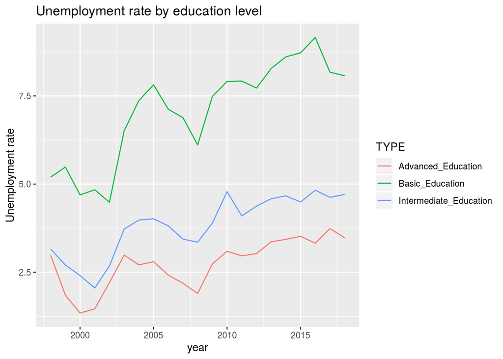

## Unemployment comparison with France, Germany and Italy

|  | iso2c | country | SL.UEM.ADVN.ZS | year |
| --- | --- | --- | --- | --- |
| 1 | CH | Switzerland | 3.4768 | 2018 |
| 2 | CH | Switzerland | 3.7398 | 2017 |
| 3 | CH | Switzerland | 3.3240 | 2016 |
| 4 | CH | Switzerland | 3.5191 | 2015 |
| 5 | CH | Switzerland | 3.4334 | 2014 |
| 6 | CH | Switzerland | 3.3651 | 2013 |
| 7 | CH | Switzerland | 3.0304 | 2012 |
| 8 | CH | Switzerland | 2.9646 | 2011 |
| 9 | CH | Switzerland | 3.0952 | 2010 |
| 10 | CH | Switzerland | 2.7361 | 2009 |

[output cut: 66 more lines]

|  | iso2c | country | Advanced_EducationC | year |
| --- | --- | --- | --- | --- |
| 1 | CH | Switzerland | 3.4768 | 2018 |
| 2 | CH | Switzerland | 3.7398 | 2017 |
| 3 | CH | Switzerland | 3.3240 | 2016 |
| 4 | CH | Switzerland | 3.5191 | 2015 |
| 5 | CH | Switzerland | 3.4334 | 2014 |
| 6 | CH | Switzerland | 3.3651 | 2013 |
| 7 | CH | Switzerland | 3.0304 | 2012 |
| 8 | CH | Switzerland | 2.9646 | 2011 |
| 9 | CH | Switzerland | 3.0952 | 2010 |
| 10 | CH | Switzerland | 2.7361 | 2009 |

[output cut: 66 more lines]

|  | iso2c | country | SL.UEM.INTM.ZS | year |
| --- | --- | --- | --- | --- |
| 1 | CH | Switzerland | 4.7062 | 2018 |
| 2 | CH | Switzerland | 4.6245 | 2017 |
| 3 | CH | Switzerland | 4.8255 | 2016 |
| 4 | CH | Switzerland | 4.4913 | 2015 |
| 5 | CH | Switzerland | 4.6672 | 2014 |
| 6 | CH | Switzerland | 4.5849 | 2013 |
| 7 | CH | Switzerland | 4.3743 | 2012 |
| 8 | CH | Switzerland | 4.0960 | 2011 |
| 9 | CH | Switzerland | 4.7848 | 2010 |
| 10 | CH | Switzerland | 3.8946 | 2009 |

[output cut: 66 more lines]

|  | iso2c | country | Intermediate_EducationC | year |
| --- | --- | --- | --- | --- |
| 1 | CH | Switzerland | 4.7062 | 2018 |
| 2 | CH | Switzerland | 4.6245 | 2017 |
| 3 | CH | Switzerland | 4.8255 | 2016 |
| 4 | CH | Switzerland | 4.4913 | 2015 |
| 5 | CH | Switzerland | 4.6672 | 2014 |
| 6 | CH | Switzerland | 4.5849 | 2013 |
| 7 | CH | Switzerland | 4.3743 | 2012 |
| 8 | CH | Switzerland | 4.0960 | 2011 |
| 9 | CH | Switzerland | 4.7848 | 2010 |
| 10 | CH | Switzerland | 3.8946 | 2009 |

[output cut: 66 more lines]

|  | iso2c | country | SL.UEM.BASC.ZS | year |
| --- | --- | --- | --- | --- |
| 1 | CH | Switzerland | 8.0722 | 2018 |
| 2 | CH | Switzerland | 8.1727 | 2017 |
| 3 | CH | Switzerland | 9.1582 | 2016 |
| 4 | CH | Switzerland | 8.7209 | 2015 |
| 5 | CH | Switzerland | 8.6076 | 2014 |
| 6 | CH | Switzerland | 8.2776 | 2013 |
| 7 | CH | Switzerland | 7.7222 | 2012 |
| 8 | CH | Switzerland | 7.9208 | 2011 |
| 9 | CH | Switzerland | 7.9087 | 2010 |
| 10 | CH | Switzerland | 7.4841 | 2009 |

[output cut: 66 more lines]

|  | iso2c | country | Basic_EducationC | year |
| --- | --- | --- | --- | --- |
| 1 | CH | Switzerland | 8.0722 | 2018 |
| 2 | CH | Switzerland | 8.1727 | 2017 |
| 3 | CH | Switzerland | 9.1582 | 2016 |
| 4 | CH | Switzerland | 8.7209 | 2015 |
| 5 | CH | Switzerland | 8.6076 | 2014 |
| 6 | CH | Switzerland | 8.2776 | 2013 |
| 7 | CH | Switzerland | 7.7222 | 2012 |
| 8 | CH | Switzerland | 7.9208 | 2011 |
| 9 | CH | Switzerland | 7.9087 | 2010 |
| 10 | CH | Switzerland | 7.4841 | 2009 |

[output cut: 66 more lines]

| iso2c | country | Advanced_EducationC | year | iso2c1 | country1 | Intermediate_EducationC | year1 | iso2c2 | country2 | Basic_EducationC | year2 |
| --- | --- | --- | --- | --- | --- | --- | --- | --- | --- | --- | --- |
| CH | Switzerland | 3.4768 | 2018 | CH | Switzerland | 4.7062 | 2018 | CH | Switzerland | 8.0722 | 2018 |
| CH | Switzerland | 3.7398 | 2017 | CH | Switzerland | 4.6245 | 2017 | CH | Switzerland | 8.1727 | 2017 |
| CH | Switzerland | 3.3240 | 2016 | CH | Switzerland | 4.8255 | 2016 | CH | Switzerland | 9.1582 | 2016 |
| CH | Switzerland | 3.5191 | 2015 | CH | Switzerland | 4.4913 | 2015 | CH | Switzerland | 8.7209 | 2015 |
| CH | Switzerland | 3.4334 | 2014 | CH | Switzerland | 4.6672 | 2014 | CH | Switzerland | 8.6076 | 2014 |
| CH | Switzerland | 3.3651 | 2013 | CH | Switzerland | 4.5849 | 2013 | CH | Switzerland | 8.2776 | 2013 |
| CH | Switzerland | 3.0304 | 2012 | CH | Switzerland | 4.3743 | 2012 | CH | Switzerland | 7.7222 | 2012 |
| CH | Switzerland | 2.9646 | 2011 | CH | Switzerland | 4.0960 | 2011 | CH | Switzerland | 7.9208 | 2011 |
| CH | Switzerland | 3.0952 | 2010 | CH | Switzerland | 4.7848 | 2010 | CH | Switzerland | 7.9087 | 2010 |
| CH | Switzerland | 2.7361 | 2009 | CH | Switzerland | 3.8946 | 2009 | CH | Switzerland | 7.4841 | 2009 |

[output cut: 66 more lines]

| country | Advanced_EducationC | year | Intermediate_EducationC | Basic_EducationC |
| --- | --- | --- | --- | --- |
| Switzerland | 3.4768 | 2018 | 4.7062 | 8.0722 |
| Switzerland | 3.7398 | 2017 | 4.6245 | 8.1727 |
| Switzerland | 3.3240 | 2016 | 4.8255 | 9.1582 |
| Switzerland | 3.5191 | 2015 | 4.4913 | 8.7209 |
| Switzerland | 3.4334 | 2014 | 4.6672 | 8.6076 |
| Switzerland | 3.3651 | 2013 | 4.5849 | 8.2776 |
| Switzerland | 3.0304 | 2012 | 4.3743 | 7.7222 |
| Switzerland | 2.9646 | 2011 | 4.0960 | 7.9208 |
| Switzerland | 3.0952 | 2010 | 4.7848 | 7.9087 |
| Switzerland | 2.7361 | 2009 | 3.8946 | 7.4841 |

[output cut: 66 more lines]

| country | year | Advanced_EducationC | Intermediate_EducationC | Basic_EducationC |
| --- | --- | --- | --- | --- |
| Switzerland | 2018 | 3.4768 | 4.7062 | 8.0722 |
| Switzerland | 2017 | 3.7398 | 4.6245 | 8.1727 |
| Switzerland | 2016 | 3.3240 | 4.8255 | 9.1582 |
| Switzerland | 2015 | 3.5191 | 4.4913 | 8.7209 |
| Switzerland | 2014 | 3.4334 | 4.6672 | 8.6076 |
| Switzerland | 2013 | 3.3651 | 4.5849 | 8.2776 |
| Switzerland | 2012 | 3.0304 | 4.3743 | 7.7222 |
| Switzerland | 2011 | 2.9646 | 4.0960 | 7.9208 |
| Switzerland | 2010 | 3.0952 | 4.7848 | 7.9087 |
| Switzerland | 2009 | 2.7361 | 3.8946 | 7.4841 |

[output cut: 66 more lines]

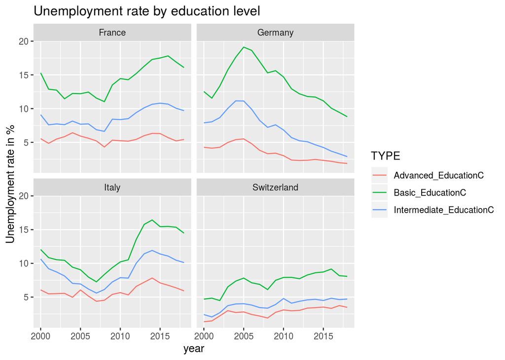

## What are Switzerland’s sources of income?

|  | iso2c | country | TX.VAL.MRCH.HI.ZS | year |
| --- | --- | --- | --- | --- |
| 1 | CH | Switzerland | NA | 2018 |
| 2 | CH | Switzerland | 75.15783 | 2017 |
| 3 | CH | Switzerland | 78.73114 | 2016 |
| 4 | CH | Switzerland | 76.92209 | 2015 |
| 5 | CH | Switzerland | 77.31181 | 2014 |
| 6 | CH | Switzerland | 75.07458 | 2013 |
| 7 | CH | Switzerland | 76.97287 | 2012 |
| 8 | CH | Switzerland | 84.12774 | 2011 |
| 9 | CH | Switzerland | 84.88724 | 2010 |
| 10 | CH | Switzerland | 85.84735 | 2009 |

[output cut: 38 more lines]

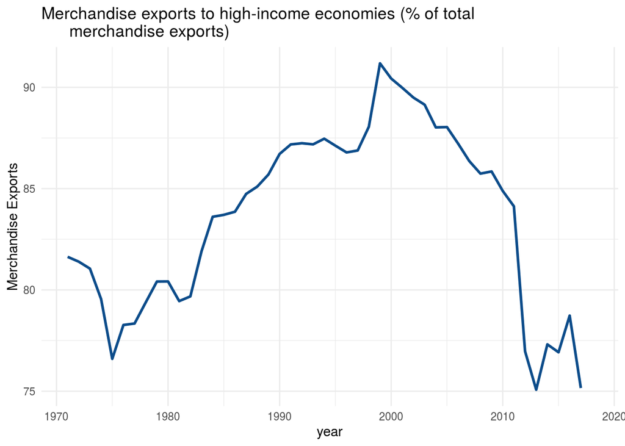

|  | iso2c | country | TM.VAL.MRCH.OR.ZS | year |
| --- | --- | --- | --- | --- |
| 1 | CH | Switzerland | NA | 2018 |
| 2 | CH | Switzerland | 19.240612 | 2017 |
| 3 | CH | Switzerland | 20.315479 | 2016 |
| 4 | CH | Switzerland | 19.984923 | 2015 |
| 5 | CH | Switzerland | 19.233959 | 2014 |
| 6 | CH | Switzerland | 16.384648 | 2013 |
| 7 | CH | Switzerland | 18.283675 | 2012 |
| 8 | CH | Switzerland | 11.192074 | 2011 |
| 9 | CH | Switzerland | 11.226132 | 2010 |
| 10 | CH | Switzerland | 10.530649 | 2009 |

[output cut: 38 more lines]

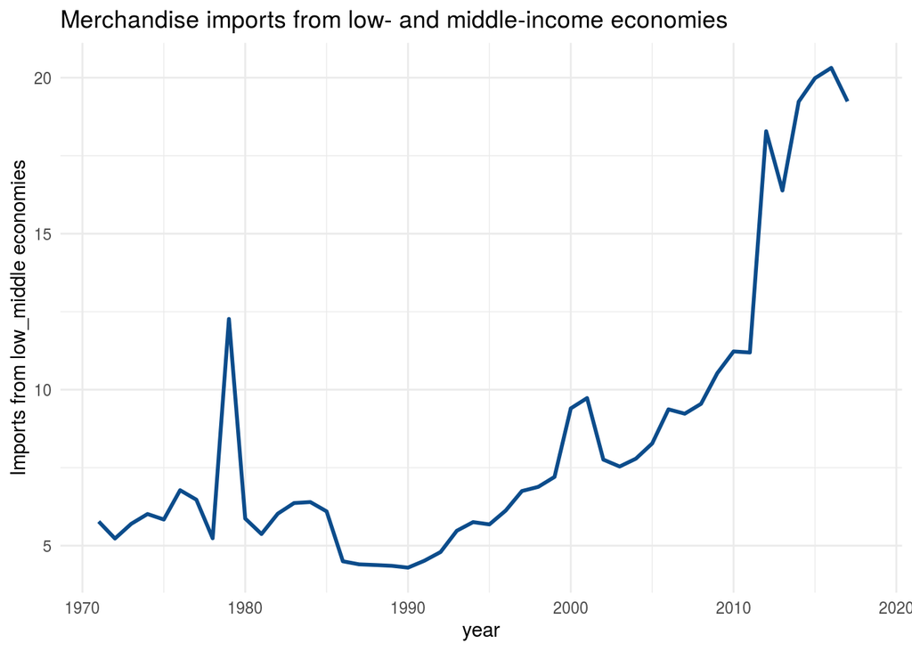

### Conclusion about Switzerland imports and exports partners (correct the sentences)

We can see that the Switzerland imports a bit (19,24%) from low / middle economies in 2017 but this is really increasing since 2010. About the exports, Switzerland exports a lot to high-income economies (75,15%) in 2017 but this is decreasing since 2010. As a conclusion, we can say that Switzerland tend to import more from low / middle economies but also to export more to these economies. However, the most of exports / imports of Switzerland are made with high-income economies but the low / middle economies increase their parts during last decade.

## Social progress index in Switzerland compared to France, Italy and Germany

| countryName | var_code | var_year | var_indicator | value |
| --- | --- | --- | --- | --- |
| France | FRA | 2014 | SPI | 87.1 |
| Germany | DEU | 2014 | SPI | 87.89 |
| Italy | ITA | 2014 | SPI | 84.41 |
| Switzerland | CHE | 2014 | SPI | 87.83 |
| France | FRA | 2015 | SPI | 87.19 |
| Germany | DEU | 2015 | SPI | 88.06 |
| Italy | ITA | 2015 | SPI | 84.63 |
| Switzerland | CHE | 2015 | SPI | 88.07 |
| France | FRA | 2016 | SPI | 87.48 |
| Germany | DEU | 2016 | SPI | 88.41 |

[output cut: 14 more lines]

| countryName | var_code | var_year | var_indicator | value |
| --- | --- | --- | --- | --- |
| France | FRA | 2014 | SPI | 87.10 |
| Germany | DEU | 2014 | SPI | 87.89 |
| Italy | ITA | 2014 | SPI | 84.41 |
| Switzerland | CHE | 2014 | SPI | 87.83 |
| France | FRA | 2015 | SPI | 87.19 |
| Germany | DEU | 2015 | SPI | 88.06 |
| Italy | ITA | 2015 | SPI | 84.63 |
| Switzerland | CHE | 2015 | SPI | 88.07 |
| France | FRA | 2016 | SPI | 87.48 |
| Germany | DEU | 2016 | SPI | 88.41 |
| Italy | ITA | 2016 | SPI | 84.87 |
| Switzerland | CHE | 2016 | SPI | 88.20 |
| France | FRA | 2017 | SPI | 87.60 |
| Germany | DEU | 2017 | SPI | 88.49 |
| Italy | ITA | 2017 | SPI | 85.56 |
| Switzerland | CHE | 2017 | SPI | 88.93 |
| France | FRA | 2018 | SPI | 87.69 |
| Germany | DEU | 2018 | SPI | 88.54 |
| Italy | ITA | 2018 | SPI | 85.99 |
| Switzerland | CHE | 2018 | SPI | 88.97 |
| France | FRA | 2019 | SPI | 87.79 |
| Germany | DEU | 2019 | SPI | 88.84 |
| Italy | ITA | 2019 | SPI | 85.69 |
| Switzerland | CHE | 2019 | SPI | 89.89 |

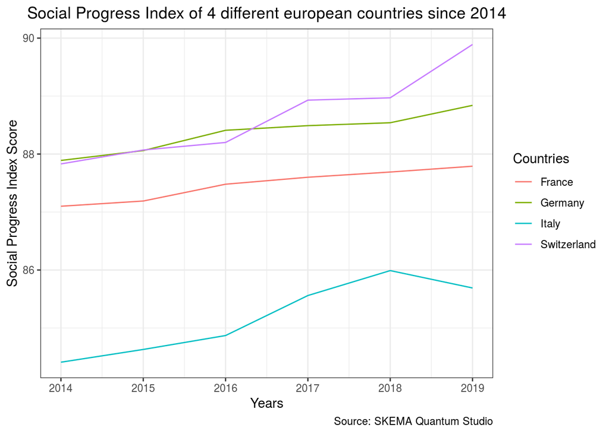